# Risk Factor Analysis

## Outcome Variable

**Outcome Variable:** y_rate_haz

## Predictor Variables

**Intervention Variable:** nhh

**Adjustment Set:**

unadjusted

## Stratifying Variables

The analysis was stratified on these variable(s):

- agecat
- studyid
- country

## Data Summary

| agecat | studyid | country | nhh | n_cell | n |
| --- | --- | --- | --- | --- | --- |
| 0-3 months | ki1000108-IRC | INDIA | 3 or less | 53 | 377 |
| 0-3 months | ki1000108-IRC | INDIA | 4-5 | 146 | 377 |
| 0-3 months | ki1000108-IRC | INDIA | 6-7 | 99 | 377 |
| 0-3 months | ki1000108-IRC | INDIA | 8+ | 79 | 377 |
| 0-3 months | ki1017093-NIH-Birth | BANGLADESH | 3 or less | 101 | 566 |
| 0-3 months | ki1017093-NIH-Birth | BANGLADESH | 4-5 | 239 | 566 |
| 0-3 months | ki1017093-NIH-Birth | BANGLADESH | 6-7 | 132 | 566 |
| 0-3 months | ki1017093-NIH-Birth | BANGLADESH | 8+ | 94 | 566 |
| 0-3 months | ki1017093b-PROVIDE | BANGLADESH | 3 or less | 123 | 634 |
| 0-3 months | ki1017093b-PROVIDE | BANGLADESH | 4-5 | 291 | 634 |
| 0-3 months | ki1017093b-PROVIDE | BANGLADESH | 6-7 | 135 | 634 |
| 0-3 months | ki1017093b-PROVIDE | BANGLADESH | 8+ | 85 | 634 |
| 0-3 months | ki1017093c-NIH-Crypto | BANGLADESH | 3 or less | 107 | 720 |
| 0-3 months | ki1017093c-NIH-Crypto | BANGLADESH | 4-5 | 324 | 720 |
| 0-3 months | ki1017093c-NIH-Crypto | BANGLADESH | 6-7 | 169 | 720 |
| 0-3 months | ki1017093c-NIH-Crypto | BANGLADESH | 8+ | 120 | 720 |
| 3-6 months | ki1000108-IRC | INDIA | 3 or less | 57 | 397 |
| 3-6 months | ki1000108-IRC | INDIA | 4-5 | 154 | 397 |
| 3-6 months | ki1000108-IRC | INDIA | 6-7 | 103 | 397 |
| 3-6 months | ki1000108-IRC | INDIA | 8+ | 83 | 397 |
| 3-6 months | ki1017093-NIH-Birth | BANGLADESH | 3 or less | 89 | 523 |
| 3-6 months | ki1017093-NIH-Birth | BANGLADESH | 4-5 | 223 | 523 |
| 3-6 months | ki1017093-NIH-Birth | BANGLADESH | 6-7 | 126 | 523 |
| 3-6 months | ki1017093-NIH-Birth | BANGLADESH | 8+ | 85 | 523 |
| 3-6 months | ki1017093b-PROVIDE | BANGLADESH | 3 or less | 102 | 574 |
| 3-6 months | ki1017093b-PROVIDE | BANGLADESH | 4-5 | 270 | 574 |
| 3-6 months | ki1017093b-PROVIDE | BANGLADESH | 6-7 | 124 | 574 |
| 3-6 months | ki1017093b-PROVIDE | BANGLADESH | 8+ | 78 | 574 |
| 3-6 months | ki1017093c-NIH-Crypto | BANGLADESH | 3 or less | 101 | 695 |
| 3-6 months | ki1017093c-NIH-Crypto | BANGLADESH | 4-5 | 316 | 695 |
| 3-6 months | ki1017093c-NIH-Crypto | BANGLADESH | 6-7 | 163 | 695 |
| 3-6 months | ki1017093c-NIH-Crypto | BANGLADESH | 8+ | 115 | 695 |
| 6-12 months | ki1000108-IRC | INDIA | 3 or less | 57 | 400 |
| 6-12 months | ki1000108-IRC | INDIA | 4-5 | 154 | 400 |
| 6-12 months | ki1000108-IRC | INDIA | 6-7 | 104 | 400 |
| 6-12 months | ki1000108-IRC | INDIA | 8+ | 85 | 400 |
| 6-12 months | ki1000304b-SAS-FoodSuppl | INDIA | 3 or less | 26 | 332 |
| 6-12 months | ki1000304b-SAS-FoodSuppl | INDIA | 4-5 | 146 | 332 |
| 6-12 months | ki1000304b-SAS-FoodSuppl | INDIA | 6-7 | 106 | 332 |
| 6-12 months | ki1000304b-SAS-FoodSuppl | INDIA | 8+ | 54 | 332 |
| 6-12 months | ki1017093-NIH-Birth | BANGLADESH | 3 or less | 87 | 482 |
| 6-12 months | ki1017093-NIH-Birth | BANGLADESH | 4-5 | 202 | 482 |
| 6-12 months | ki1017093-NIH-Birth | BANGLADESH | 6-7 | 112 | 482 |
| 6-12 months | ki1017093-NIH-Birth | BANGLADESH | 8+ | 81 | 482 |
| 6-12 months | ki1017093b-PROVIDE | BANGLADESH | 3 or less | 97 | 545 |
| 6-12 months | ki1017093b-PROVIDE | BANGLADESH | 4-5 | 258 | 545 |
| 6-12 months | ki1017093b-PROVIDE | BANGLADESH | 6-7 | 114 | 545 |
| 6-12 months | ki1017093b-PROVIDE | BANGLADESH | 8+ | 76 | 545 |
| 6-12 months | ki1017093c-NIH-Crypto | BANGLADESH | 3 or less | 95 | 676 |
| 6-12 months | ki1017093c-NIH-Crypto | BANGLADESH | 4-5 | 307 | 676 |
| 6-12 months | ki1017093c-NIH-Crypto | BANGLADESH | 6-7 | 164 | 676 |
| 6-12 months | ki1017093c-NIH-Crypto | BANGLADESH | 8+ | 110 | 676 |
| 6-12 months | ki1148112-LCNI-5 | MALAWI | 3 or less | 119 | 430 |
| 6-12 months | ki1148112-LCNI-5 | MALAWI | 4-5 | 183 | 430 |
| 6-12 months | ki1148112-LCNI-5 | MALAWI | 6-7 | 95 | 430 |
| 6-12 months | ki1148112-LCNI-5 | MALAWI | 8+ | 33 | 430 |
| 12-24 months | ki1000108-IRC | INDIA | 3 or less | 57 | 396 |
| 12-24 months | ki1000108-IRC | INDIA | 4-5 | 151 | 396 |
| 12-24 months | ki1000108-IRC | INDIA | 6-7 | 103 | 396 |
| 12-24 months | ki1000108-IRC | INDIA | 8+ | 85 | 396 |
| 12-24 months | ki1017093-NIH-Birth | BANGLADESH | 3 or less | 74 | 421 |
| 12-24 months | ki1017093-NIH-Birth | BANGLADESH | 4-5 | 181 | 421 |
| 12-24 months | ki1017093-NIH-Birth | BANGLADESH | 6-7 | 97 | 421 |
| 12-24 months | ki1017093-NIH-Birth | BANGLADESH | 8+ | 69 | 421 |
| 12-24 months | ki1017093b-PROVIDE | BANGLADESH | 3 or less | 86 | 458 |
| 12-24 months | ki1017093b-PROVIDE | BANGLADESH | 4-5 | 213 | 458 |
| 12-24 months | ki1017093b-PROVIDE | BANGLADESH | 6-7 | 96 | 458 |
| 12-24 months | ki1017093b-PROVIDE | BANGLADESH | 8+ | 63 | 458 |
| 12-24 months | ki1017093c-NIH-Crypto | BANGLADESH | 3 or less | 68 | 495 |
| 12-24 months | ki1017093c-NIH-Crypto | BANGLADESH | 4-5 | 224 | 495 |
| 12-24 months | ki1017093c-NIH-Crypto | BANGLADESH | 6-7 | 125 | 495 |
| 12-24 months | ki1017093c-NIH-Crypto | BANGLADESH | 8+ | 78 | 495 |
| 12-24 months | ki1148112-LCNI-5 | MALAWI | 3 or less | 89 | 307 |
| 12-24 months | ki1148112-LCNI-5 | MALAWI | 4-5 | 130 | 307 |
| 12-24 months | ki1148112-LCNI-5 | MALAWI | 6-7 | 64 | 307 |
| 12-24 months | ki1148112-LCNI-5 | MALAWI | 8+ | 24 | 307 |

The following strata were considered:

- agecat: 0-3 months, studyid: ki1000108-IRC, country: INDIA
- agecat: 0-3 months, studyid: ki1017093-NIH-Birth, country: BANGLADESH
- agecat: 0-3 months, studyid: ki1017093b-PROVIDE, country: BANGLADESH
- agecat: 0-3 months, studyid: ki1017093c-NIH-Crypto, country: BANGLADESH
- agecat: 12-24 months, studyid: ki1000108-IRC, country: INDIA
- agecat: 12-24 months, studyid: ki1017093-NIH-Birth, country: BANGLADESH
- agecat: 12-24 months, studyid: ki1017093b-PROVIDE, country: BANGLADESH
- agecat: 12-24 months, studyid: ki1017093c-NIH-Crypto, country: BANGLADESH
- agecat: 12-24 months, studyid: ki1148112-LCNI-5, country: MALAWI
- agecat: 3-6 months, studyid: ki1000108-IRC, country: INDIA
- agecat: 3-6 months, studyid: ki1017093-NIH-Birth, country: BANGLADESH
- agecat: 3-6 months, studyid: ki1017093b-PROVIDE, country: BANGLADESH
- agecat: 3-6 months, studyid: ki1017093c-NIH-Crypto, country: BANGLADESH
- agecat: 6-12 months, studyid: ki1000108-IRC, country: INDIA
- agecat: 6-12 months, studyid: ki1000304b-SAS-FoodSuppl, country: INDIA
- agecat: 6-12 months, studyid: ki1017093-NIH-Birth, country: BANGLADESH
- agecat: 6-12 months, studyid: ki1017093b-PROVIDE, country: BANGLADESH
- agecat: 6-12 months, studyid: ki1017093c-NIH-Crypto, country: BANGLADESH
- agecat: 6-12 months, studyid: ki1148112-LCNI-5, country: MALAWI

## Methods Detail

We’re interested in the causal parameters $E[Y_a]$ for all values of $a \in \mathcal{A}$. These parameters represent the mean outcome if, possibly contrary to fact, we intervened to set all units to have $A=a$. Under the randomization and positivity assumptions, these are identified by the statistical parameters $\psi_a=E_W[E_{Y|A,W}(Y|A=a,W)]$. In addition, we’re interested in the mean of $Y$, $E[Y]$ under no intervention (the observed mean). We will estimate these parameters by using SuperLearner to fit the relevant likelihood factors – $E_{Y|A,W}(Y|A=a,W)$ and $p(A=a|W)$, and then updating our likelihood fit using a joint TMLE.

For unadjusted analyses ($W=\{\}$), initial likelihoods were estimated using Lrnr_glm to estimate the simple $E(Y|A)$ and Lrnr_mean to estimate $p(A)$. For adjusted analyses, a small library containing Lrnr_glmnet, Lrnr_xgboost, and Lrnr_mean was used.

# Results Detail

## Results Plots

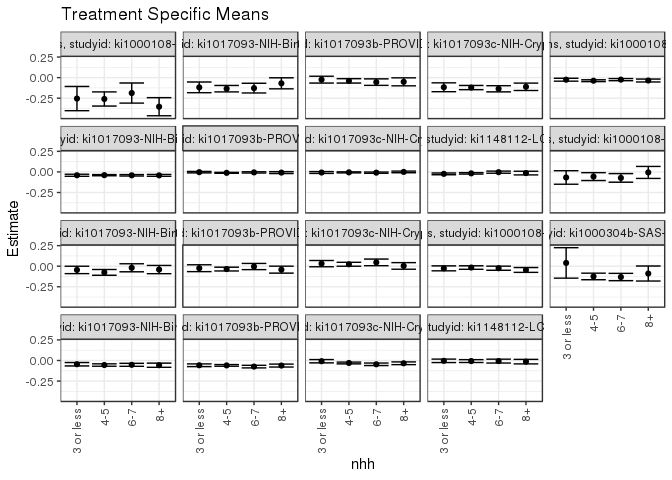

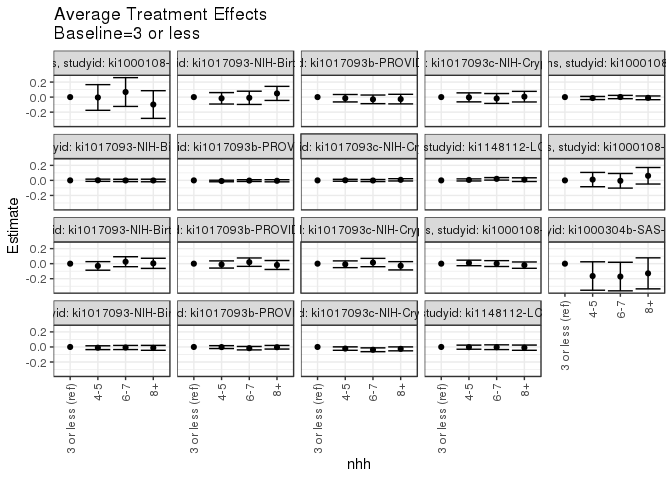

## Results Table

### Parameter: TSM

| agecat | studyid | country | intervention_level | baseline_level | estimate | ci_lower | ci_upper |
| --- | --- | --- | --- | --- | --- | --- | --- |
| 0-3 months | ki1000108-IRC | INDIA | 3 or less | NA | -0.2546692 | -0.4020239 | -0.1073144 |
| 0-3 months | ki1000108-IRC | INDIA | 4-5 | NA | -0.2594418 | -0.3455000 | -0.1733835 |
| 0-3 months | ki1000108-IRC | INDIA | 6-7 | NA | -0.1872275 | -0.3092502 | -0.0652048 |
| 0-3 months | ki1000108-IRC | INDIA | 8+ | NA | -0.3534005 | -0.4634050 | -0.2433960 |
| 0-3 months | ki1017093-NIH-Birth | BANGLADESH | 3 or less | NA | -0.1182345 | -0.1833800 | -0.0530891 |
| 0-3 months | ki1017093-NIH-Birth | BANGLADESH | 4-5 | NA | -0.1343925 | -0.1736014 | -0.0951836 |
| 0-3 months | ki1017093-NIH-Birth | BANGLADESH | 6-7 | NA | -0.1276316 | -0.1865972 | -0.0686661 |
| 0-3 months | ki1017093-NIH-Birth | BANGLADESH | 8+ | NA | -0.0692667 | -0.1364275 | -0.0021060 |
| 0-3 months | ki1017093b-PROVIDE | BANGLADESH | 3 or less | NA | -0.0245411 | -0.0660283 | 0.0169461 |
| 0-3 months | ki1017093b-PROVIDE | BANGLADESH | 4-5 | NA | -0.0393529 | -0.0661390 | -0.0125668 |
| 0-3 months | ki1017093b-PROVIDE | BANGLADESH | 6-7 | NA | -0.0546672 | -0.0941664 | -0.0151680 |
| 0-3 months | ki1017093b-PROVIDE | BANGLADESH | 8+ | NA | -0.0510935 | -0.0995256 | -0.0026615 |
| 0-3 months | ki1017093c-NIH-Crypto | BANGLADESH | 3 or less | NA | -0.1171054 | -0.1712058 | -0.0630051 |
| 0-3 months | ki1017093c-NIH-Crypto | BANGLADESH | 4-5 | NA | -0.1207461 | -0.1462781 | -0.0952141 |
| 0-3 months | ki1017093c-NIH-Crypto | BANGLADESH | 6-7 | NA | -0.1355042 | -0.1730816 | -0.0979269 |
| 0-3 months | ki1017093c-NIH-Crypto | BANGLADESH | 8+ | NA | -0.1112240 | -0.1562130 | -0.0662350 |
| 3-6 months | ki1000108-IRC | INDIA | 3 or less | NA | -0.0675296 | -0.1496225 | 0.0145633 |
| 3-6 months | ki1000108-IRC | INDIA | 4-5 | NA | -0.0567931 | -0.1046158 | -0.0089703 |
| 3-6 months | ki1000108-IRC | INDIA | 6-7 | NA | -0.0727749 | -0.1250467 | -0.0205031 |
| 3-6 months | ki1000108-IRC | INDIA | 8+ | NA | -0.0061435 | -0.0791299 | 0.0668429 |
| 3-6 months | ki1017093-NIH-Birth | BANGLADESH | 3 or less | NA | -0.0451535 | -0.0901732 | -0.0001338 |
| 3-6 months | ki1017093-NIH-Birth | BANGLADESH | 4-5 | NA | -0.0750228 | -0.1099796 | -0.0400660 |
| 3-6 months | ki1017093-NIH-Birth | BANGLADESH | 6-7 | NA | -0.0191869 | -0.0678666 | 0.0294929 |
| 3-6 months | ki1017093-NIH-Birth | BANGLADESH | 8+ | NA | -0.0406444 | -0.0908712 | 0.0095824 |
| 3-6 months | ki1017093b-PROVIDE | BANGLADESH | 3 or less | NA | -0.0241209 | -0.0657276 | 0.0174859 |
| 3-6 months | ki1017093b-PROVIDE | BANGLADESH | 4-5 | NA | -0.0349136 | -0.0578027 | -0.0120244 |
| 3-6 months | ki1017093b-PROVIDE | BANGLADESH | 6-7 | NA | -0.0039961 | -0.0415279 | 0.0335357 |
| 3-6 months | ki1017093b-PROVIDE | BANGLADESH | 8+ | NA | -0.0417289 | -0.0841267 | 0.0006688 |
| 3-6 months | ki1017093c-NIH-Crypto | BANGLADESH | 3 or less | NA | 0.0314652 | -0.0065418 | 0.0694722 |
| 3-6 months | ki1017093c-NIH-Crypto | BANGLADESH | 4-5 | NA | 0.0235468 | -0.0003394 | 0.0474329 |
| 3-6 months | ki1017093c-NIH-Crypto | BANGLADESH | 6-7 | NA | 0.0465722 | 0.0063682 | 0.0867762 |
| 3-6 months | ki1017093c-NIH-Crypto | BANGLADESH | 8+ | NA | 0.0034601 | -0.0367595 | 0.0436798 |
| 6-12 months | ki1000108-IRC | INDIA | 3 or less | NA | -0.0258994 | -0.0560316 | 0.0042327 |
| 6-12 months | ki1000108-IRC | INDIA | 4-5 | NA | -0.0162847 | -0.0373870 | 0.0048175 |
| 6-12 months | ki1000108-IRC | INDIA | 6-7 | NA | -0.0245324 | -0.0494405 | 0.0003758 |
| 6-12 months | ki1000108-IRC | INDIA | 8+ | NA | -0.0455360 | -0.0748551 | -0.0162169 |
| 6-12 months | ki1000304b-SAS-FoodSuppl | INDIA | 3 or less | NA | 0.0398181 | -0.1450804 | 0.2247165 |
| 6-12 months | ki1000304b-SAS-FoodSuppl | INDIA | 4-5 | NA | -0.1243685 | -0.1642881 | -0.0844489 |
| 6-12 months | ki1000304b-SAS-FoodSuppl | INDIA | 6-7 | NA | -0.1314211 | -0.1755986 | -0.0872436 |
| 6-12 months | ki1000304b-SAS-FoodSuppl | INDIA | 8+ | NA | -0.0890105 | -0.1804176 | 0.0023965 |
| 6-12 months | ki1017093-NIH-Birth | BANGLADESH | 3 or less | NA | -0.0453335 | -0.0660294 | -0.0246377 |
| 6-12 months | ki1017093-NIH-Birth | BANGLADESH | 4-5 | NA | -0.0551169 | -0.0696603 | -0.0405735 |
| 6-12 months | ki1017093-NIH-Birth | BANGLADESH | 6-7 | NA | -0.0524693 | -0.0703590 | -0.0345795 |
| 6-12 months | ki1017093-NIH-Birth | BANGLADESH | 8+ | NA | -0.0572697 | -0.0825715 | -0.0319680 |
| 6-12 months | ki1017093b-PROVIDE | BANGLADESH | 3 or less | NA | -0.0578762 | -0.0742296 | -0.0415227 |
| 6-12 months | ki1017093b-PROVIDE | BANGLADESH | 4-5 | NA | -0.0596235 | -0.0695566 | -0.0496903 |
| 6-12 months | ki1017093b-PROVIDE | BANGLADESH | 6-7 | NA | -0.0740626 | -0.0899685 | -0.0581566 |
| 6-12 months | ki1017093b-PROVIDE | BANGLADESH | 8+ | NA | -0.0616484 | -0.0796319 | -0.0436648 |
| 6-12 months | ki1017093c-NIH-Crypto | BANGLADESH | 3 or less | NA | -0.0086875 | -0.0288864 | 0.0115115 |
| 6-12 months | ki1017093c-NIH-Crypto | BANGLADESH | 4-5 | NA | -0.0302026 | -0.0408920 | -0.0195132 |
| 6-12 months | ki1017093c-NIH-Crypto | BANGLADESH | 6-7 | NA | -0.0458978 | -0.0610658 | -0.0307297 |
| 6-12 months | ki1017093c-NIH-Crypto | BANGLADESH | 8+ | NA | -0.0337613 | -0.0503884 | -0.0171342 |
| 6-12 months | ki1148112-LCNI-5 | MALAWI | 3 or less | NA | -0.0041425 | -0.0251160 | 0.0168310 |
| 6-12 months | ki1148112-LCNI-5 | MALAWI | 4-5 | NA | -0.0070317 | -0.0244777 | 0.0104142 |
| 6-12 months | ki1148112-LCNI-5 | MALAWI | 6-7 | NA | -0.0072473 | -0.0308494 | 0.0163549 |
| 6-12 months | ki1148112-LCNI-5 | MALAWI | 8+ | NA | -0.0137292 | -0.0413779 | 0.0139194 |
| 12-24 months | ki1000108-IRC | INDIA | 3 or less | NA | -0.0252096 | -0.0427700 | -0.0076491 |
| 12-24 months | ki1000108-IRC | INDIA | 4-5 | NA | -0.0374590 | -0.0484565 | -0.0264615 |
| 12-24 months | ki1000108-IRC | INDIA | 6-7 | NA | -0.0243372 | -0.0374225 | -0.0112519 |
| 12-24 months | ki1000108-IRC | INDIA | 8+ | NA | -0.0350636 | -0.0525214 | -0.0176058 |
| 12-24 months | ki1017093-NIH-Birth | BANGLADESH | 3 or less | NA | -0.0407408 | -0.0534699 | -0.0280116 |
| 12-24 months | ki1017093-NIH-Birth | BANGLADESH | 4-5 | NA | -0.0391987 | -0.0463151 | -0.0320822 |
| 12-24 months | ki1017093-NIH-Birth | BANGLADESH | 6-7 | NA | -0.0414198 | -0.0501069 | -0.0327327 |
| 12-24 months | ki1017093-NIH-Birth | BANGLADESH | 8+ | NA | -0.0419221 | -0.0530925 | -0.0307517 |
| 12-24 months | ki1017093b-PROVIDE | BANGLADESH | 3 or less | NA | -0.0030412 | -0.0115121 | 0.0054297 |
| 12-24 months | ki1017093b-PROVIDE | BANGLADESH | 4-5 | NA | -0.0112664 | -0.0169828 | -0.0055499 |
| 12-24 months | ki1017093b-PROVIDE | BANGLADESH | 6-7 | NA | -0.0058231 | -0.0135207 | 0.0018745 |
| 12-24 months | ki1017093b-PROVIDE | BANGLADESH | 8+ | NA | -0.0082914 | -0.0197086 | 0.0031257 |
| 12-24 months | ki1017093c-NIH-Crypto | BANGLADESH | 3 or less | NA | -0.0073331 | -0.0185279 | 0.0038618 |
| 12-24 months | ki1017093c-NIH-Crypto | BANGLADESH | 4-5 | NA | -0.0054193 | -0.0114415 | 0.0006029 |
| 12-24 months | ki1017093c-NIH-Crypto | BANGLADESH | 6-7 | NA | -0.0090179 | -0.0165877 | -0.0014480 |
| 12-24 months | ki1017093c-NIH-Crypto | BANGLADESH | 8+ | NA | 0.0000279 | -0.0098789 | 0.0099346 |
| 12-24 months | ki1148112-LCNI-5 | MALAWI | 3 or less | NA | -0.0236605 | -0.0341427 | -0.0131783 |
| 12-24 months | ki1148112-LCNI-5 | MALAWI | 4-5 | NA | -0.0175457 | -0.0262358 | -0.0088555 |
| 12-24 months | ki1148112-LCNI-5 | MALAWI | 6-7 | NA | -0.0032746 | -0.0162484 | 0.0096991 |
| 12-24 months | ki1148112-LCNI-5 | MALAWI | 8+ | NA | -0.0139286 | -0.0361693 | 0.0083122 |

### Parameter: E(Y)

| agecat | studyid | country | intervention_level | baseline_level | estimate | ci_lower | ci_upper |
| --- | --- | --- | --- | --- | --- | --- | --- |
| 0-3 months | ki1000108-IRC | INDIA | NA | NA | -0.2594964 | -0.3154509 | -0.2035418 |
| 0-3 months | ki1017093-NIH-Birth | BANGLADESH | NA | NA | -0.1191165 | -0.1460676 | -0.0921654 |
| 0-3 months | ki1017093b-PROVIDE | BANGLADESH | NA | NA | -0.0413143 | -0.0594662 | -0.0231624 |
| 0-3 months | ki1017093c-NIH-Crypto | BANGLADESH | NA | NA | -0.1220821 | -0.1402761 | -0.1038881 |
| 3-6 months | ki1000108-IRC | INDIA | NA | NA | -0.0518918 | -0.0819849 | -0.0217987 |
| 3-6 months | ki1017093-NIH-Birth | BANGLADESH | NA | NA | -0.0509007 | -0.0730097 | -0.0287917 |
| 3-6 months | ki1017093b-PROVIDE | BANGLADESH | NA | NA | -0.0272428 | -0.0436954 | -0.0107902 |
| 3-6 months | ki1017093c-NIH-Crypto | BANGLADESH | NA | NA | 0.0267740 | 0.0099602 | 0.0435879 |
| 6-12 months | ki1000108-IRC | INDIA | NA | NA | -0.0260151 | -0.0389122 | -0.0131180 |
| 6-12 months | ki1000304b-SAS-FoodSuppl | INDIA | NA | NA | -0.1080113 | -0.1390238 | -0.0769988 |
| 6-12 months | ki1017093-NIH-Birth | BANGLADESH | NA | NA | -0.0530976 | -0.0624028 | -0.0437924 |
| 6-12 months | ki1017093b-PROVIDE | BANGLADESH | NA | NA | -0.0626151 | -0.0695574 | -0.0556729 |
| 6-12 months | ki1017093c-NIH-Crypto | BANGLADESH | NA | NA | -0.0315658 | -0.0388594 | -0.0242722 |
| 6-12 months | ki1148112-LCNI-5 | MALAWI | NA | NA | -0.0067938 | -0.0177737 | 0.0041862 |
| 12-24 months | ki1000108-IRC | INDIA | NA | NA | -0.0317687 | -0.0388357 | -0.0247017 |
| 12-24 months | ki1017093-NIH-Birth | BANGLADESH | NA | NA | -0.0404278 | -0.0450901 | -0.0357656 |
| 12-24 months | ki1017093b-PROVIDE | BANGLADESH | NA | NA | -0.0081718 | -0.0120131 | -0.0043304 |
| 12-24 months | ki1017093c-NIH-Crypto | BANGLADESH | NA | NA | -0.0057326 | -0.0097260 | -0.0017391 |
| 12-24 months | ki1148112-LCNI-5 | MALAWI | NA | NA | -0.0160605 | -0.0218715 | -0.0102495 |

### Parameter: ATE

| agecat | studyid | country | intervention_level | baseline_level | estimate | ci_lower | ci_upper |
| --- | --- | --- | --- | --- | --- | --- | --- |
| 0-3 months | ki1000108-IRC | INDIA | 3 or less | 3 or less | 0.0000000 | 0.0000000 | 0.0000000 |
| 0-3 months | ki1000108-IRC | INDIA | 4-5 | 3 or less | -0.0047726 | -0.1754169 | 0.1658716 |
| 0-3 months | ki1000108-IRC | INDIA | 6-7 | 3 or less | 0.0674416 | -0.1238774 | 0.2587607 |
| 0-3 months | ki1000108-IRC | INDIA | 8+ | 3 or less | -0.0987313 | -0.2826183 | 0.0851557 |
| 0-3 months | ki1017093-NIH-Birth | BANGLADESH | 3 or less | 3 or less | 0.0000000 | 0.0000000 | 0.0000000 |
| 0-3 months | ki1017093-NIH-Birth | BANGLADESH | 4-5 | 3 or less | -0.0161580 | -0.0921927 | 0.0598767 |
| 0-3 months | ki1017093-NIH-Birth | BANGLADESH | 6-7 | 3 or less | -0.0093971 | -0.0972656 | 0.0784713 |
| 0-3 months | ki1017093-NIH-Birth | BANGLADESH | 8+ | 3 or less | 0.0489678 | -0.0445977 | 0.1425333 |
| 0-3 months | ki1017093b-PROVIDE | BANGLADESH | 3 or less | 3 or less | 0.0000000 | 0.0000000 | 0.0000000 |
| 0-3 months | ki1017093b-PROVIDE | BANGLADESH | 4-5 | 3 or less | -0.0148118 | -0.0641948 | 0.0345712 |
| 0-3 months | ki1017093b-PROVIDE | BANGLADESH | 6-7 | 3 or less | -0.0301261 | -0.0874094 | 0.0271572 |
| 0-3 months | ki1017093b-PROVIDE | BANGLADESH | 8+ | 3 or less | -0.0265525 | -0.0903243 | 0.0372194 |
| 0-3 months | ki1017093c-NIH-Crypto | BANGLADESH | 3 or less | 3 or less | 0.0000000 | 0.0000000 | 0.0000000 |
| 0-3 months | ki1017093c-NIH-Crypto | BANGLADESH | 4-5 | 3 or less | -0.0036407 | -0.0634632 | 0.0561818 |
| 0-3 months | ki1017093c-NIH-Crypto | BANGLADESH | 6-7 | 3 or less | -0.0183988 | -0.0842692 | 0.0474716 |
| 0-3 months | ki1017093c-NIH-Crypto | BANGLADESH | 8+ | 3 or less | 0.0058814 | -0.0644809 | 0.0762438 |
| 3-6 months | ki1000108-IRC | INDIA | 3 or less | 3 or less | 0.0000000 | 0.0000000 | 0.0000000 |
| 3-6 months | ki1000108-IRC | INDIA | 4-5 | 3 or less | 0.0107365 | -0.0842701 | 0.1057431 |
| 3-6 months | ki1000108-IRC | INDIA | 6-7 | 3 or less | -0.0052453 | -0.1025674 | 0.0920767 |
| 3-6 months | ki1000108-IRC | INDIA | 8+ | 3 or less | 0.0613861 | -0.0484604 | 0.1712326 |
| 3-6 months | ki1017093-NIH-Birth | BANGLADESH | 3 or less | 3 or less | 0.0000000 | 0.0000000 | 0.0000000 |
| 3-6 months | ki1017093-NIH-Birth | BANGLADESH | 4-5 | 3 or less | -0.0298693 | -0.0868671 | 0.0271285 |
| 3-6 months | ki1017093-NIH-Birth | BANGLADESH | 6-7 | 3 or less | 0.0259667 | -0.0403393 | 0.0922727 |
| 3-6 months | ki1017093-NIH-Birth | BANGLADESH | 8+ | 3 or less | 0.0045091 | -0.0629409 | 0.0719591 |
| 3-6 months | ki1017093b-PROVIDE | BANGLADESH | 3 or less | 3 or less | 0.0000000 | 0.0000000 | 0.0000000 |
| 3-6 months | ki1017093b-PROVIDE | BANGLADESH | 4-5 | 3 or less | -0.0107927 | -0.0582799 | 0.0366945 |
| 3-6 months | ki1017093b-PROVIDE | BANGLADESH | 6-7 | 3 or less | 0.0201248 | -0.0359088 | 0.0761583 |
| 3-6 months | ki1017093b-PROVIDE | BANGLADESH | 8+ | 3 or less | -0.0176081 | -0.0770109 | 0.0417947 |
| 3-6 months | ki1017093c-NIH-Crypto | BANGLADESH | 3 or less | 3 or less | 0.0000000 | 0.0000000 | 0.0000000 |
| 3-6 months | ki1017093c-NIH-Crypto | BANGLADESH | 4-5 | 3 or less | -0.0079184 | -0.0528080 | 0.0369712 |
| 3-6 months | ki1017093c-NIH-Crypto | BANGLADESH | 6-7 | 3 or less | 0.0151070 | -0.0402183 | 0.0704324 |
| 3-6 months | ki1017093c-NIH-Crypto | BANGLADESH | 8+ | 3 or less | -0.0280050 | -0.0833418 | 0.0273317 |
| 6-12 months | ki1000108-IRC | INDIA | 3 or less | 3 or less | 0.0000000 | 0.0000000 | 0.0000000 |
| 6-12 months | ki1000108-IRC | INDIA | 4-5 | 3 or less | 0.0096147 | -0.0271719 | 0.0464013 |
| 6-12 months | ki1000108-IRC | INDIA | 6-7 | 3 or less | 0.0013671 | -0.0377272 | 0.0404614 |
| 6-12 months | ki1000108-IRC | INDIA | 8+ | 3 or less | -0.0196365 | -0.0616789 | 0.0224058 |
| 6-12 months | ki1000304b-SAS-FoodSuppl | INDIA | 3 or less | 3 or less | 0.0000000 | 0.0000000 | 0.0000000 |
| 6-12 months | ki1000304b-SAS-FoodSuppl | INDIA | 4-5 | 3 or less | -0.1641866 | -0.3533453 | 0.0249721 |
| 6-12 months | ki1000304b-SAS-FoodSuppl | INDIA | 6-7 | 3 or less | -0.1712392 | -0.3613420 | 0.0188637 |
| 6-12 months | ki1000304b-SAS-FoodSuppl | INDIA | 8+ | 3 or less | -0.1288286 | -0.3350874 | 0.0774302 |
| 6-12 months | ki1017093-NIH-Birth | BANGLADESH | 3 or less | 3 or less | 0.0000000 | 0.0000000 | 0.0000000 |
| 6-12 months | ki1017093-NIH-Birth | BANGLADESH | 4-5 | 3 or less | -0.0097834 | -0.0350782 | 0.0155115 |
| 6-12 months | ki1017093-NIH-Birth | BANGLADESH | 6-7 | 3 or less | -0.0071358 | -0.0344919 | 0.0202204 |
| 6-12 months | ki1017093-NIH-Birth | BANGLADESH | 8+ | 3 or less | -0.0119362 | -0.0446240 | 0.0207517 |
| 6-12 months | ki1017093b-PROVIDE | BANGLADESH | 3 or less | 3 or less | 0.0000000 | 0.0000000 | 0.0000000 |
| 6-12 months | ki1017093b-PROVIDE | BANGLADESH | 4-5 | 3 or less | -0.0017473 | -0.0208811 | 0.0173865 |
| 6-12 months | ki1017093b-PROVIDE | BANGLADESH | 6-7 | 3 or less | -0.0161864 | -0.0389995 | 0.0066267 |
| 6-12 months | ki1017093b-PROVIDE | BANGLADESH | 8+ | 3 or less | -0.0037722 | -0.0280794 | 0.0205350 |
| 6-12 months | ki1017093c-NIH-Crypto | BANGLADESH | 3 or less | 3 or less | 0.0000000 | 0.0000000 | 0.0000000 |
| 6-12 months | ki1017093c-NIH-Crypto | BANGLADESH | 4-5 | 3 or less | -0.0215151 | -0.0443681 | 0.0013380 |
| 6-12 months | ki1017093c-NIH-Crypto | BANGLADESH | 6-7 | 3 or less | -0.0372103 | -0.0624703 | -0.0119503 |
| 6-12 months | ki1017093c-NIH-Crypto | BANGLADESH | 8+ | 3 or less | -0.0250738 | -0.0512360 | 0.0010883 |
| 6-12 months | ki1148112-LCNI-5 | MALAWI | 3 or less | 3 or less | 0.0000000 | 0.0000000 | 0.0000000 |
| 6-12 months | ki1148112-LCNI-5 | MALAWI | 4-5 | 3 or less | -0.0028892 | -0.0301702 | 0.0243917 |
| 6-12 months | ki1148112-LCNI-5 | MALAWI | 6-7 | 3 or less | -0.0031048 | -0.0346793 | 0.0284697 |
| 6-12 months | ki1148112-LCNI-5 | MALAWI | 8+ | 3 or less | -0.0095868 | -0.0442903 | 0.0251168 |
| 12-24 months | ki1000108-IRC | INDIA | 3 or less | 3 or less | 0.0000000 | 0.0000000 | 0.0000000 |
| 12-24 months | ki1000108-IRC | INDIA | 4-5 | 3 or less | -0.0122495 | -0.0329694 | 0.0084704 |
| 12-24 months | ki1000108-IRC | INDIA | 6-7 | 3 or less | 0.0008724 | -0.0210273 | 0.0227720 |
| 12-24 months | ki1000108-IRC | INDIA | 8+ | 3 or less | -0.0098541 | -0.0346158 | 0.0149077 |
| 12-24 months | ki1017093-NIH-Birth | BANGLADESH | 3 or less | 3 or less | 0.0000000 | 0.0000000 | 0.0000000 |
| 12-24 months | ki1017093-NIH-Birth | BANGLADESH | 4-5 | 3 or less | 0.0015421 | -0.0130413 | 0.0161255 |
| 12-24 months | ki1017093-NIH-Birth | BANGLADESH | 6-7 | 3 or less | -0.0006790 | -0.0160900 | 0.0147319 |
| 12-24 months | ki1017093-NIH-Birth | BANGLADESH | 8+ | 3 or less | -0.0011814 | -0.0181168 | 0.0157541 |
| 12-24 months | ki1017093b-PROVIDE | BANGLADESH | 3 or less | 3 or less | 0.0000000 | 0.0000000 | 0.0000000 |
| 12-24 months | ki1017093b-PROVIDE | BANGLADESH | 4-5 | 3 or less | -0.0082252 | -0.0184444 | 0.0019941 |
| 12-24 months | ki1017093b-PROVIDE | BANGLADESH | 6-7 | 3 or less | -0.0027819 | -0.0142278 | 0.0086640 |
| 12-24 months | ki1017093b-PROVIDE | BANGLADESH | 8+ | 3 or less | -0.0052502 | -0.0194667 | 0.0089662 |
| 12-24 months | ki1017093c-NIH-Crypto | BANGLADESH | 3 or less | 3 or less | 0.0000000 | 0.0000000 | 0.0000000 |
| 12-24 months | ki1017093c-NIH-Crypto | BANGLADESH | 4-5 | 3 or less | 0.0019138 | -0.0107981 | 0.0146257 |
| 12-24 months | ki1017093c-NIH-Crypto | BANGLADESH | 6-7 | 3 or less | -0.0016848 | -0.0151988 | 0.0118292 |
| 12-24 months | ki1017093c-NIH-Crypto | BANGLADESH | 8+ | 3 or less | 0.0073609 | -0.0075879 | 0.0223098 |
| 12-24 months | ki1148112-LCNI-5 | MALAWI | 3 or less | 3 or less | 0.0000000 | 0.0000000 | 0.0000000 |
| 12-24 months | ki1148112-LCNI-5 | MALAWI | 4-5 | 3 or less | 0.0061148 | -0.0075012 | 0.0197308 |
| 12-24 months | ki1148112-LCNI-5 | MALAWI | 6-7 | 3 or less | 0.0203859 | 0.0037067 | 0.0370650 |
| 12-24 months | ki1148112-LCNI-5 | MALAWI | 8+ | 3 or less | 0.0097319 | -0.0148553 | 0.0343191 |